# Homework Assignment 2

Data Science and Machine Learning 2 - CEU 2018

Kristof Menyhert

2018-04-03

Load some packages:

```r
library(data.table)
library(knitr)
library(kableExtra)
library(magrittr)
library(keras)
library(h2o)
h2o.init()
```

```r
data <- fread("C:/Users/Chronos/OneDrive - Central European University/R/machine_learning1/hw2/no-show-data.csv")
# some data cleaning
data[, c("PatientId", "AppointmentID", "Neighbourhood") := NULL]
setnames(data,
         c("No-show",
           "Age",
           "Gender",
           "ScheduledDay",
           "AppointmentDay",
           "Scholarship",
           "Hipertension",
           "Diabetes",
           "Alcoholism",
           "Handcap",
           "SMS_received"),
         c("no_show",
           "age",
           "gender",
           "scheduled_day",
           "appointment_day",
           "scholarship",
           "hypertension",
           "diabetes",
           "alcoholism",
           "handicap",
           "sms_received"))
# for binary prediction, the target variable must be a factor
data[, no_show := factor(no_show, levels = c("Yes", "No"))]
data[, handicap := ifelse(handicap > 0, 1, 0)]
# create new variables
data[, gender := factor(gender)]
data[, scholarship := factor(scholarship)]
data[, hypertension := factor(hypertension)]
data[, alcoholism := factor(alcoholism)]
data[, handicap := factor(handicap)]
data[, scheduled_day := as.Date(scheduled_day)]
data[, appointment_day := as.Date(appointment_day)]
data[, days_since_scheduled := as.integer(appointment_day - scheduled_day)]
# clean up a little bit
data <- data[age %between% c(0, 95)]
data <- data[days_since_scheduled > -1]
data[, c("scheduled_day", "appointment_day", "sms_received") := NULL]
```

```r
h2o.nrow(data)
```

## 1) Deep learning with `h2o` (7 points)

*Please for all models you are building, use `reproducible = TRUE` option so that conclusions that you draw are not dependent on the particular run of your models. Also, please set the same seed.*

1. Create train / validation / test sets, cutting the data into 5% - 45% - 50% parts.

```r
splitted_data <- h2o.splitFrame(data,
                                ratios = c(0.05, 0.45),
                                seed = 123)
data_train <- splitted_data[[1]]
data_valid <- splitted_data[[2]]
data_test <- splitted_data[[3]]

#check if the split is right or not:
h2o.nrow(data) == h2o.nrow(data_train) + h2o.nrow(data_valid) + h2o.nrow(data_test)
```

Setting up Y and Xs variables

```r
Y <- "no_show"
X <- setdiff(names(data), c(Y, "no_show"))
```

2. Train a benchmark model of your choice using h2o (such as random forest, gbm or glm) and evaluate it on the validation set.

I am doing a RF model for benchmarking.

```r
rf_model <- h2o.getModel(h2o.getGrid(rf_grid@grid_id)@model_ids[[1]]) #get the best model
```

[output not shown]

Get the AUC for the validation set:

```r
h2o.auc(h2o.performance(rf_model, newdata = data_valid))
```

[output not shown]

3. Build deep learning models. Experiment with parameter settings regarding
   - network topology (varying number of layers and nodes within layers)
   - activation function
   - dropout (both hidden and input layers)
   - lasso, ridge regularization
   - early stopping (changing stopping rounds, tolerance) and number of epochs

For all models, supply the validation_frame and use AUC as a stopping metric. Present different model versions and evaluate them on the validation set. Which one performs the best?

```r
h2o.getGrid(grid_id = dl_model0@grid_id, sort_by = "AUC", decreasing = TRUE)
```

[output not shown]

```r
h2o.getGrid(grid_id = dl_model1@grid_id, sort_by = "AUC", decreasing = TRUE)
```

[output not shown]

```r
dl_model <- h2o.getModel(h2o.getGrid(dl_model1@grid_id)@model_ids[[1]])
```

4. How does your best model compare to the benchmark model on the test set?

```r
# AUC on the benchmark model on the test set:
test_set_benchmark_auc <- h2o.auc(h2o.performance(rf_model, newdata = data_test))

# AUC of the best DL model on the test set:
test_set_dl_auc <- h2o.auc(h2o.performance(dl_model, newdata = data_test))

aucs <- cbind(test_set_benchmark_auc, test_set_dl_auc)

kable_styling(kable(aucs, col.names = c("AUC of RF model","AUC of the DL model"), digits = 4, align = c("c")), bootstrap_options = c("striped", "hover", "condensed"), full_width = F)
```

[output not shown]

5. Evaluate the model that performs best based on the validation set on the test set.

It is the same answer.

## 2) Stacking with h2o (6 points)

Take the same problem and data splits.

1. Build at least 4 models of different families using cross validation, keeping cross validated predictions.
2. Evaluate validation set performance of each model.

```r
rf_auc <- h2o.auc(h2o.performance(simple_rf, newdata = data_valid))
gbm_auc <- h2o.auc(h2o.performance(simple_gbm, newdata = data_valid))
logit_auc <- h2o.auc(h2o.performance(simple_logit, newdata = data_valid))
dl_auc <- h2o.auc(h2o.performance(simple_dl, newdata = data_valid))

simple_model_aucs <- cbind(rf_auc, gbm_auc, logit_auc, dl_auc)

kable_styling(kable(simple_model_aucs, col.names = c("RF AUC","GBM AUC", "LOGIT AUC", "DL AUC"), digits = 4, align = c("c")), bootstrap_options = c("striped", "hover", "condensed"), full_width = F)
```

[output not shown]

3. How large are the correlations of predicted scores of the validation set produced by the base learners?

```r
kable_styling(kable(cor_matrix, digits = 4, align = c("c")), bootstrap_options = c("striped", "hover", "condensed"), full_width = F)
```

[output not shown]

4. Create a stacked ensemble model from the base learners. Experiment with at least two different ensembling meta learners.

5. Evaluate ensembles on validation set. Did it improve prediction?

```r
ensambel_auc_valid <- h2o.auc(h2o.performance(ensemble_model, newdata = data_valid))

ensambel_auc_valid
```

[output not shown]

6. Evaluate the best performing model on the test set. How does performance compare to that of the validation set?

```r
ensambel_auc_test <- h2o.auc(h2o.performance(ensemble_model, newdata = data_test))

ensambel_auc_test
```

[output not shown]

## 3) Fashion image classification using keras (0 points - only for fun)

Take the “Fashion MNIST dataset” where images of fashion items are to be classified in a similar manner to what we saw with handwritten digits (see more here[https://github.com/zalandoresearch/fashion-mnist]). Images are in exactly the same format as we saw digits: 28x28 pixel grayscale images. The task is to build deep neural net models to predict image classes. The goal is to have as accurate classifier as possible: we are using accuracy as a measure of predictive power.

```r
fashion_mnist <- dataset_fashion_mnist()
x_train <- fashion_mnist$train$x
y_train <- fashion_mnist$train$y
x_test <- fashion_mnist$test$x
y_test <- fashion_mnist$test$y
```

1. Show some example images from the data.

```r
show_image <- function(x) {
  image(1:28, 1:28, t(x)[,nrow(x):1],col=gray((0:255)/255))
}

show_image(x_train[100, , ])
```

[output not shown]

2. Train a fully connected deep network to predict items.
- Normalize the data similarly to what we saw with MNIST.
- Experiment with network architectures and settings (number of hidden layers, number of nodes, activation functions, etc.)
- Explain what you have tried, what worked and what did not. Present a final model.
- Make sure that you use enough epochs so that the validation error starts flattening out - provide a plot about the training history (`plot(history)`)

```r
# reshape
x_train <- array_reshape(x_train, c(dim(x_train)[1], 784))
x_test <- array_reshape(x_test, c(dim(x_test)[1], 784))
# rescale = normalizing
x_train <- x_train / 255
x_test <- x_test / 255

# one-hot encoding of the target variable
y_train <- to_categorical(y_train, 10)
y_test <- to_categorical(y_test, 10)
```

```r
model <- keras_model_sequential()
model %>%
  layer_dense(units = 128, activation = 'relu', input_shape = c(784)) %>%
  layer_dropout(rate = 0.3) %>%
  layer_dense(units = 64, activation = 'relu') %>%
  layer_dropout(rate = 0.2) %>%
  layer_dense(units = 32, activation = 'relu') %>%
  layer_dense(units = 10, activation = 'softmax')
```

```r
summary(model)
```

```r
model %>% compile(
  loss = 'categorical_crossentropy',
  optimizer = optimizer_rmsprop(),
  metrics = c('accuracy')
)
```

```r
history <- model %>% fit(
  x_train, y_train,
  epochs = 20,
  batch_size = 128,
  validation_split = 0.2
)
```

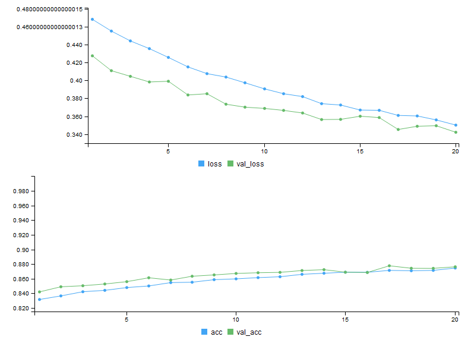

loss and accuracy

3. Evaluate the model on the test set. How does test error compare to validation error?

```r
model %>% evaluate(x_test, y_test)
```

[output not shown]